# Scholarly API Cookbook

Contents

# …in Mathematica

## CAS Common Chemistry API in Mathematica

by Vishank Patel

These recipe examples were tested on March 31, 2022 using Mathematica 12.3.

**CAS Common Chemistry API Documentation (requires registration):** https://www.cas.org/services/commonchemistry-api

**Attribution:** This tutorial uses the [CAS Common Chemistry](https://commonchemistry.cas.org/) API. Example data shown is licensed under the [CC BY-NC 4.0 license](https://creativecommons.org/licenses/by-nc/4.0/).

### 1. Common Chemistry Record Detail Retrieval

Information about substances in CAS Common Chemistry can be retrieved using the `/detail` API and a CAS RN identifier:

#### Setup API Parameters

```
detailBaseURL = "https://commonchemistry.cas.org/api/detail?";
casrn1 = "10094-36-7" ; (*ethyl cyclohexanepropionate*)
```

#### Request data from CAS Common Chemistry Detail API

```
casrn1Data = Import[detailBaseURL <> "cas_rn=" <> casrn1, "RawJSON"];
casrn1Data
```

*Output not shown*

```
casrn1Data //OutputForm (*Changed to plain text output*)
```

```
<|uri -> substance/pt/10094367, rn -> 10094-36-7, name -> Ethyl cyclohexanepropionate,

>   image -> <svg width="228.6" viewBox="0 0 7620 3716" text-rendering="auto"\

>     stroke-width="1" stroke-opacity="1" stroke-miterlimit="10" stroke-linejoin="miter"\

>     stroke-linecap="square" stroke-dashoffset="0" stroke-dasharray="none"\

>     stroke="black" shape-rendering="auto" image-rendering="auto" height="111.48"\

>     font-weight="normal" font-style="normal" font-size="12" font-family="'Dialog'"\

>     fill-opacity="1" fill="black" color-rendering="auto" color-interpolation="auto"\

>     xmlns="http://www.w3.org/2000/svg"><g><g stroke="white" fill="white"><rect y="0"\

>     x="0" width="7620" stroke="none" height="3716"/></g><g\

>     transform="translate(32866,32758)" text-rendering="geometricPrecision"\

>     stroke-width="44" stroke-linejoin="round" stroke-linecap="round"><line y2="-30850"\

>     y1="-31419" x2="-30792" x1="-31777" fill="none"/><line y2="-29715" y1="-30850"\

>     x2="-30792" x1="-30792" fill="none"/><line y2="-31419" y1="-30850" x2="-31777"\

>     x1="-32762" fill="none"/><line y2="-29146" y1="-29715" x2="-31777" x1="-30792"\

>     fill="none"/><line y2="-30850" y1="-29715" x2="-32762" x1="-32762"\

>     fill="none"/><line y2="-29715" y1="-29146" x2="-32762" x1="-31777"\

>     fill="none"/><line y2="-31376" y1="-30850" x2="-29885" x1="-30792"\

>     fill="none"/><line y2="-30850" y1="-31376" x2="-28978" x1="-29885"\

>     fill="none"/><line y2="-31376" y1="-30850" x2="-28071" x1="-28978"\

>     fill="none"/><line y2="-30960" y1="-31376" x2="-27352" x1="-28071"\

>     fill="none"/><line y2="-31376" y1="-30960" x2="-26257" x1="-26976"\

>     fill="none"/><line y2="-30850" y1="-31376" x2="-25350" x1="-26257"\

>     fill="none"/><line y2="-32202" y1="-31376" x2="-28140" x1="-28140"\

>     fill="none"/><line y2="-32202" y1="-31376" x2="-28002" x1="-28002"\

>     fill="none"/><text y="-30671" xml:space="preserve" x="-27317" stroke="none"\

>     font-size="433.3333" font-family="sans-serif">O</text><text y="-32242"\

>     xml:space="preserve" x="-28224" stroke="none" font-size="433.3333"\

>     font-family="sans-serif">O</text></g></g></svg>,

>   inchi -> InChI=1S/C11H20O2/c1-2-13-11(12)9-8-10-6-4-3-5-7-10/h10H,2-9H2,1H3,

>   inchiKey -> InChIKey=NRVPMFHPHGBQLP-UHFFFAOYSA-N, smile -> C(CC(OCC)=O)C1CCCCC1,

>   canonicalSmile -> O=C(OCC)CCC1CCCCC1,

>   molecularFormula -> C<sub>11</sub>H<sub>20</sub>O<sub>2</sub>,

>   molecularMass -> 184.28, experimentalProperties ->

>    {<|name -> Boiling Point, property -> 105-113 °C @ Press: 17 Torr,

>      sourceNumber -> 1|>}, propertyCitations ->

>    {<|docUri -> document/pt/document/22252593, sourceNumber -> 1,

>      source -> De Benneville, Peter L.; Journal of the American Chemical Society,\

>        (1940), 62, 283-7, CAplus|>},

>   synonyms -> {Cyclohexanepropanoic acid, ethyl ester,

>     Cyclohexanepropionic acid, ethyl ester, Ethyl cyclohexanepropionate,

>     Ethyl cyclohexylpropanoate, Ethyl 3-cyclohexylpropionate,

>     Ethyl 3-cyclohexylpropanoate, 3-Cyclohexylpropionic acid ethyl ester, NSC 71463,

>     Ethyl 3-cyclohexanepropionate}, replacedRns -> {}, hasMolfile -> True|>
```

#### Display the Molecule Drawing

```
MoleculePlot[casrn1Data["smile"]]
```

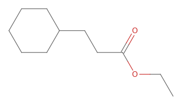

#### Select some specific data

Get experimental properties:

```
casrn1Data["experimentalProperties"][[1]]
```

```
<|name -> Boiling Point, property -> 105-113 °C @ Press: 17 Torr, sourceNumber -> 1|>
```

Get boiling point property

```
casrn1Data["experimentalProperties"][[1]]["property"]
```

```
105-113 °C @ Press: 17 Torr
```

Get InChIKey

```
casrn1Data["inchiKey"]
```

```
InChIKey=NRVPMFHPHGBQLP-UHFFFAOYSA-N
```

```
casrn1Data["canonicalSmile"]
```

```
O=C(OCC)CCC1CCCCC1
```

### 2. Common Chemistry API record detail retrieval in a loop

#### Setup API parameters

```
detailBaseURLLoop = "https://commonchemistry.cas.org/api/detail?";
casrnList = {"10094-36-7", "10031-92-2", "10199-61-8", "10036-21-2","1019020-13-3"};
```

#### Request data for each CAS RN and save to a list

```
casrnData = {};
For[i = 1, i <= Length[casrnList], i++,
 AppendTo[casrnData,
  Import[detailBaseURL <> "cas_rn=" <> casrnList[[i]], "RawJSON"]]
 ]
```

```
casrnData[[1]]
```

*Output not shown*

```
casrnData[[1]] //OutputForm (*Changed to plain text output*)
```

```
<|uri -> substance/pt/10094367, rn -> 10094-36-7, name -> Ethyl cyclohexanepropionate,

>   image -> <svg width="228.6" viewBox="0 0 7620 3716" text-rendering="auto"\

>     stroke-width="1" stroke-opacity="1" stroke-miterlimit="10" stroke-linejoin="miter"\

>     stroke-linecap="square" stroke-dashoffset="0" stroke-dasharray="none"\

>     stroke="black" shape-rendering="auto" image-rendering="auto" height="111.48"\

>     font-weight="normal" font-style="normal" font-size="12" font-family="'Dialog'"\

>     fill-opacity="1" fill="black" color-rendering="auto" color-interpolation="auto"\

>     xmlns="http://www.w3.org/2000/svg"><g><g stroke="white" fill="white"><rect y="0"\

>     x="0" width="7620" stroke="none" height="3716"/></g><g\

>     transform="translate(32866,32758)" text-rendering="geometricPrecision"\

>     stroke-width="44" stroke-linejoin="round" stroke-linecap="round"><line y2="-30850"\

>     y1="-31419" x2="-30792" x1="-31777" fill="none"/><line y2="-29715" y1="-30850"\

>     x2="-30792" x1="-30792" fill="none"/><line y2="-31419" y1="-30850" x2="-31777"\

>     x1="-32762" fill="none"/><line y2="-29146" y1="-29715" x2="-31777" x1="-30792"\

>     fill="none"/><line y2="-30850" y1="-29715" x2="-32762" x1="-32762"\

>     fill="none"/><line y2="-29715" y1="-29146" x2="-32762" x1="-31777"\

>     fill="none"/><line y2="-31376" y1="-30850" x2="-29885" x1="-30792"\

>     fill="none"/><line y2="-30850" y1="-31376" x2="-28978" x1="-29885"\

>     fill="none"/><line y2="-31376" y1="-30850" x2="-28071" x1="-28978"\

>     fill="none"/><line y2="-30960" y1="-31376" x2="-27352" x1="-28071"\

>     fill="none"/><line y2="-31376" y1="-30960" x2="-26257" x1="-26976"\

>     fill="none"/><line y2="-30850" y1="-31376" x2="-25350" x1="-26257"\

>     fill="none"/><line y2="-32202" y1="-31376" x2="-28140" x1="-28140"\

>     fill="none"/><line y2="-32202" y1="-31376" x2="-28002" x1="-28002"\

>     fill="none"/><text y="-30671" xml:space="preserve" x="-27317" stroke="none"\

>     font-size="433.3333" font-family="sans-serif">O</text><text y="-32242"\

>     xml:space="preserve" x="-28224" stroke="none" font-size="433.3333"\

>     font-family="sans-serif">O</text></g></g></svg>,

>   inchi -> InChI=1S/C11H20O2/c1-2-13-11(12)9-8-10-6-4-3-5-7-10/h10H,2-9H2,1H3,

>   inchiKey -> InChIKey=NRVPMFHPHGBQLP-UHFFFAOYSA-N, smile -> C(CC(OCC)=O)C1CCCCC1,

>   canonicalSmile -> O=C(OCC)CCC1CCCCC1,

>   molecularFormula -> C<sub>11</sub>H<sub>20</sub>O<sub>2</sub>,

>   molecularMass -> 184.28, experimentalProperties ->

>    {<|name -> Boiling Point, property -> 105-113 °C @ Press: 17 Torr,

>      sourceNumber -> 1|>}, propertyCitations ->

>    {<|docUri -> document/pt/document/22252593, sourceNumber -> 1,

>      source -> De Benneville, Peter L.; Journal of the American Chemical Society,\

>        (1940), 62, 283-7, CAplus|>},

>   synonyms -> {Cyclohexanepropanoic acid, ethyl ester,

>     Cyclohexanepropionic acid, ethyl ester, Ethyl cyclohexanepropionate,

>     Ethyl cyclohexylpropanoate, Ethyl 3-cyclohexylpropionate,

>     Ethyl 3-cyclohexylpropanoate, 3-Cyclohexylpropionic acid ethyl ester, NSC 71463,

>     Ethyl 3-cyclohexanepropionate}, replacedRns -> {}, hasMolfile -> True|>
```

```
plotList = {};
For[i = 1, i <= Length[casrnList], i++,
 AppendTo[plotList, MoleculePlot[casrnData[[i]]["smile"]]]
 ]
```

```
plotList
```

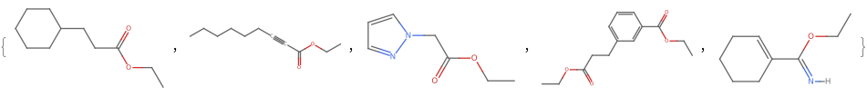

#### Select some specific data

Get canonical SMILES

```
cansmiles = {};
For[i = 1, i <= Length[casrnList], i++,
 AppendTo[cansmiles,
  casrnData[[i]]["canonicalSmile"]]
 ]
cansmiles
```

```
{O=C(OCC)CCC1CCCCC1, O=C(C#CCCCCCC)OCC, O=C(OCC)CN1N=CC=C1,

>   O=C(OCC)C1=CC=CC(=C1)CCC(=O)OCC, N=C(OCC)C1=CCCCC1}
```

```
synonymsList = {};
For[i = 1, i <= Length[casrnList], i++,
 AppendTo[synonymsList,
  casrnData[[i]]["synonyms"]]
 ]
synonymsList
```

```
{{Cyclohexanepropanoic acid, ethyl ester, Cyclohexanepropionic acid, ethyl ester,

>    Ethyl cyclohexanepropionate, Ethyl cyclohexylpropanoate,

>    Ethyl 3-cyclohexylpropionate, Ethyl 3-cyclohexylpropanoate,

>    3-Cyclohexylpropionic acid ethyl ester, NSC 71463, Ethyl 3-cyclohexanepropionate},

>   {2-Nonynoic acid, ethyl ester, Ethyl 2-nonynoate, NSC 190985},

>   {1<em>H</em>-Pyrazole-1-acetic acid, ethyl ester,

>    Pyrazole-1-acetic acid, ethyl ester, Ethyl 1<em>H</em>-pyrazole-1-acetate,

>    Ethyl 1-pyrazoleacetate, Ethyl 2-(1<em>H</em>-pyrazol-1-yl)acetate},

>   {Benzenepropanoic acid, 3-(ethoxycarbonyl)-, ethyl ester,

>    Hydrocinnamic acid, <em>m</em>-carboxy-, diethyl ester,

>    Ethyl 3-(ethoxycarbonyl)benzenepropanoate},

>   {1-Cyclohexene-1-carboximidic acid, ethyl ester,

>    Ethyl 1-cyclohexene-1-carboximidate}}
```

Transform synonym “list of lists” to a flat list

```
Flatten[synonymsList]
```

```
{Cyclohexanepropanoic acid, ethyl ester, Cyclohexanepropionic acid, ethyl ester,

>   Ethyl cyclohexanepropionate, Ethyl cyclohexylpropanoate,

>   Ethyl 3-cyclohexylpropionate, Ethyl 3-cyclohexylpropanoate,

>   3-Cyclohexylpropionic acid ethyl ester, NSC 71463, Ethyl 3-cyclohexanepropionate,

>   2-Nonynoic acid, ethyl ester, Ethyl 2-nonynoate, NSC 190985,

>   1<em>H</em>-Pyrazole-1-acetic acid, ethyl ester,

>   Pyrazole-1-acetic acid, ethyl ester, Ethyl 1<em>H</em>-pyrazole-1-acetate,

>   Ethyl 1-pyrazoleacetate, Ethyl 2-(1<em>H</em>-pyrazol-1-yl)acetate,

>   Benzenepropanoic acid, 3-(ethoxycarbonyl)-, ethyl ester,

>   Hydrocinnamic acid, <em>m</em>-carboxy-, diethyl ester,

>   Ethyl 3-(ethoxycarbonyl)benzenepropanoate,

>   1-Cyclohexene-1-carboximidic acid, ethyl ester, Ethyl 1-cyclohexene-1-carboximidate}
```

#### Create a dataset

```
Table[casrnData[[All, i]], {i, {"uri", "rn", "name"}}] // Dataset
```

```
Dataset[{{substance/pt/10094367, substance/pt/10031922, substance/pt/10199618,

>     substance/pt/10036212, substance/pt/1019020133},

>    {10094-36-7, 10031-92-2, 10199-61-8, 10036-21-2, 1019020-13-3},

>    {Ethyl cyclohexanepropionate, Ethyl 2-nonynoate,

>     Ethyl 1<em>H</em>-pyrazole-1-acetate, Ethyl 3-(ethoxycarbonyl)benzenepropanoate,

>     Ethyl 1-cyclohexene-1-carboximidate}},

>   TypeSystem`Vector[TypeSystem`Vector[TypeSystem`Atom[String], 5], 3], <||>]
```

### 3. Common Chemistry Search

In addition to the `/detail` API, the CAS Common Chemistry API has a `/search` method that allows searching by CAS RN, SMILES, InChI/InChIKey, and name.

#### Setup API Parameters

```
searchBaseURL = "https://commonchemistry.cas.org/api/search?q=";

(*InChIKey for Quinine*)
IK = "InChIKey=LOUPRKONTZGTKE-WZBLMQSHSA-N";
```

#### Request data from CAS Common Chemistry Search API

Search query:

```
quinineSearchData = Import[searchBaseURL <> IK, "RawJSON"];
quinineSearchData
```

```
<|count -> 1, results ->

>    {<|rn -> 130-95-0, name -> Quinine,

>      image -> <svg width="309.3" viewBox="0 0 10310 5592" text-rendering="auto"\

>        stroke-width="1" stroke-opacity="1" stroke-miterlimit="10"\

>        stroke-linejoin="miter" stroke-linecap="square" stroke-dashoffset="0"\

>        stroke-dasharray="none" stroke="black" shape-rendering="auto"\

>        image-rendering="auto" height="167.76" font-weight="normal" font-style="normal"\

>        font-size="12" font-family="'Dialog'" fill-opacity="1" fill="black"\

>        color-rendering="auto" color-interpolation="auto"\

>        xmlns="http://www.w3.org/2000/svg"><g><g stroke="white" fill="white"><rect\

>        y="0" x="0" width="10310" stroke="none" height="5592"/></g><g\

>        transform="translate(32866,32758)" text-rendering="geometricPrecision"\

>        stroke-width="44" stroke-linejoin="round" stroke-linecap="round"><line\

>        y2="-28559" y1="-28036" x2="-26635" x1="-25742" fill="none"/><line y2="-29819"\

>        y1="-28559" x2="-26635" x1="-26635" fill="none"/><line y2="-28036" y1="-28559"\

>        x2="-25367" x1="-24474" fill="none"/><line y2="-30451" y1="-29819" x2="-25555"\

>        x1="-26635" fill="none"/><line y2="-28559" y1="-29819" x2="-24474" x1="-24474"\

>        fill="none"/><line y2="-29504" y1="-28828" x2="-25194" x1="-26005"\

>        fill="none"/><line y2="-29819" y1="-30451" x2="-24474" x1="-25555"\

>        fill="none"/><line y2="-29082" y1="-28559" x2="-27542" x1="-26635"\

>        fill="none"/><line y2="-29819" y1="-30344" x2="-22660" x1="-23567"\

>        fill="none"/><line y2="-29700" y1="-30223" x2="-22729" x1="-23636"\

>        fill="none"/><line y2="-28779" y1="-29082" x2="-28071" x1="-27542"\

>        fill="none"/><line y2="-30703" y1="-30131" x2="-28524" x1="-27542"\

>        fill="none"/><line y2="-31850" y1="-30703" x2="-28524" x1="-28524"\

>        fill="none"/><line y2="-31705" y1="-30847" x2="-28354" x1="-28354"\

>        fill="none"/><line y2="-30131" y1="-30703" x2="-29507" x1="-28524"\

>        fill="none"/><line y2="-30131" y1="-30703" x2="-27542" x1="-26560"\

>        fill="none"/><line y2="-30347" y1="-30778" x2="-27505" x1="-26768"\

>        fill="none"/><line y2="-31850" y1="-32422" x2="-28524" x1="-29507"\

>        fill="none"/><line y2="-32312" y1="-31850" x2="-27730" x1="-28524"\

>        fill="none"/><line y2="-30703" y1="-30131" x2="-30489" x1="-29507"\

>        fill="none"/><line y2="-30778" y1="-30347" x2="-30281" x1="-29544"\

>        fill="none"/><line y2="-30703" y1="-31850" x2="-26560" x1="-26560"\

>        fill="none"/><line y2="-32422" y1="-31850" x2="-29507" x1="-30489"\

>        fill="none"/><line y2="-32205" y1="-31774" x2="-29544" x1="-30281"\

>        fill="none"/><line y2="-31850" y1="-32312" x2="-26560" x1="-27354"\

>        fill="none"/><line y2="-31760" y1="-32107" x2="-26745" x1="-27340"\

>        fill="none"/><line y2="-31850" y1="-30703" x2="-30489" x1="-30489"\

>        fill="none"/><line y2="-30275" y1="-30703" x2="-31200" x1="-30489"\

>        fill="none"/><line y2="-30541" y1="-30272" x2="-32040" x1="-31575"\

>        fill="none"/><polygon stroke-width="1" stroke="none" points=" -24474 -29819\

>        -23602 -30402 -23532 -30284"/><polygon stroke-width="1" points=" -24474 -29819\

>        -23602 -30402 -23532 -30284" fill="none"/><polygon stroke-width="1"\

>        stroke="none" points=" -26635 -28559 -26973 -27837 -27092 -27903"/><polygon\

>        stroke-width="1" points=" -26635 -28559 -26973 -27837 -27092 -27903"\

>        fill="none"/><line y2="-28860" y1="-28796" x2="-25945" x1="-26066"\

>        fill="none"/><line y2="-28657" y1="-28611" x2="-25865" x1="-25952"\

>        fill="none"/><line y2="-28454" y1="-28427" x2="-25785" x1="-25838"\

>        fill="none"/><line y2="-28252" y1="-28242" x2="-25706" x1="-25723"\

>        fill="none"/><line y2="-29478" y1="-29530" x2="-25257" x1="-25130"\

>        fill="none"/><line y2="-29686" y1="-29727" x2="-25321" x1="-25221"\

>        fill="none"/><line y2="-29894" y1="-29924" x2="-25384" x1="-25312"\

>        fill="none"/><line y2="-30102" y1="-30121" x2="-25448" x1="-25403"\

>        fill="none"/><line y2="-30310" y1="-30317" x2="-25512" x1="-25493"\

>        fill="none"/><line y2="-30131" y1="-30128" x2="-27473" x1="-27612"\

>        fill="none"/><line y2="-29914" y1="-29912" x2="-27487" x1="-27598"\

>        fill="none"/><line y2="-29697" y1="-29695" x2="-27502" x1="-27583"\

>        fill="none"/><line y2="-29480" y1="-29479" x2="-27516" x1="-27569"\

>        fill="none"/><line y2="-29263" y1="-29263" x2="-27530" x1="-27554"\

>        fill="none"/><text y="-28380" xml:space="preserve" x="-28602" stroke="none"\

>        font-size="433.3333" font-family="sans-serif">OH</text><text y="-29983"\

>        xml:space="preserve" x="-31540" stroke="none" font-size="433.3333"\

>        font-family="sans-serif">O</text><text y="-30691" xml:space="preserve"\

>        x="-32762" stroke="none" font-size="433.3333"\

>        font-family="sans-serif">CH</text><text y="-30602" xml:space="preserve"\

>        x="-32185" stroke="none" font-size="313.3333"\

>        font-family="sans-serif">3</text><text y="-32242" xml:space="preserve"\

>        x="-27695" stroke="none" font-size="433.3333"\

>        font-family="sans-serif">N</text><text y="-27747" xml:space="preserve"\

>        x="-25708" stroke="none" font-size="433.3333"\

>        font-family="sans-serif">N</text><text y="-27473" xml:space="preserve"\

>        x="-27311" stroke="none" font-size="433.3333"\

>        font-family="sans-serif">H</text><text y="-28600" xml:space="preserve"\

>        x="-27695" stroke="none" font-style="italic" font-size="313.3333"\

>        font-family="sans-serif">R</text><text y="-28522" xml:space="preserve"\

>        x="-26540" stroke="none" font-style="italic" font-size="313.3333"\

>        font-family="sans-serif">S</text><text y="-27337" xml:space="preserve"\

>        x="-25818" stroke="none" font-style="italic" font-size="313.3333"\

>        font-family="sans-serif">S</text><text y="-30573" xml:space="preserve"\

>        x="-25708" stroke="none" font-style="italic" font-size="313.3333"\

>        font-family="sans-serif">S</text><text y="-29495" xml:space="preserve"\

>        x="-24876" stroke="none" font-style="italic" font-size="313.3333"\

>        font-family="sans-serif">R</text></g></g></svg>|>}|>
```

Note that with the CAS Common Chemistry Search API, only the image data, name, and CAS RN is returned. In order to retrieve the full record, we can combine our search with the related detail API:

```
quinineRN = quinineSearchData["results"][[1, "rn"]]
```

```
130-95-0
```

```
detailBaseURL = "https://commonchemistry.cas.org/api/detail?";
quinineDetailData = Import[detailBaseURL <> "cas_rn=" <> quinineRN, "RawJSON"];
quinineDetailData
```

*Output not shown*

```
quinineDetailData //OutputForm (*Changed to plain text output*)
```

```
<|uri -> substance/pt/130950, rn -> 130-95-0, name -> Quinine,

>   image -> <svg width="309.3" viewBox="0 0 10310 5592" text-rendering="auto"\

>     stroke-width="1" stroke-opacity="1" stroke-miterlimit="10" stroke-linejoin="miter"\

>     stroke-linecap="square" stroke-dashoffset="0" stroke-dasharray="none"\

>     stroke="black" shape-rendering="auto" image-rendering="auto" height="167.76"\

>     font-weight="normal" font-style="normal" font-size="12" font-family="'Dialog'"\

>     fill-opacity="1" fill="black" color-rendering="auto" color-interpolation="auto"\

>     xmlns="http://www.w3.org/2000/svg"><g><g stroke="white" fill="white"><rect y="0"\

>     x="0" width="10310" stroke="none" height="5592"/></g><g\

>     transform="translate(32866,32758)" text-rendering="geometricPrecision"\

>     stroke-width="44" stroke-linejoin="round" stroke-linecap="round"><line y2="-28559"\

>     y1="-28036" x2="-26635" x1="-25742" fill="none"/><line y2="-29819" y1="-28559"\

>     x2="-26635" x1="-26635" fill="none"/><line y2="-28036" y1="-28559" x2="-25367"\

>     x1="-24474" fill="none"/><line y2="-30451" y1="-29819" x2="-25555" x1="-26635"\

>     fill="none"/><line y2="-28559" y1="-29819" x2="-24474" x1="-24474"\

>     fill="none"/><line y2="-29504" y1="-28828" x2="-25194" x1="-26005"\

>     fill="none"/><line y2="-29819" y1="-30451" x2="-24474" x1="-25555"\

>     fill="none"/><line y2="-29082" y1="-28559" x2="-27542" x1="-26635"\

>     fill="none"/><line y2="-29819" y1="-30344" x2="-22660" x1="-23567"\

>     fill="none"/><line y2="-29700" y1="-30223" x2="-22729" x1="-23636"\

>     fill="none"/><line y2="-28779" y1="-29082" x2="-28071" x1="-27542"\

>     fill="none"/><line y2="-30703" y1="-30131" x2="-28524" x1="-27542"\

>     fill="none"/><line y2="-31850" y1="-30703" x2="-28524" x1="-28524"\

>     fill="none"/><line y2="-31705" y1="-30847" x2="-28354" x1="-28354"\

>     fill="none"/><line y2="-30131" y1="-30703" x2="-29507" x1="-28524"\

>     fill="none"/><line y2="-30131" y1="-30703" x2="-27542" x1="-26560"\

>     fill="none"/><line y2="-30347" y1="-30778" x2="-27505" x1="-26768"\

>     fill="none"/><line y2="-31850" y1="-32422" x2="-28524" x1="-29507"\

>     fill="none"/><line y2="-32312" y1="-31850" x2="-27730" x1="-28524"\

>     fill="none"/><line y2="-30703" y1="-30131" x2="-30489" x1="-29507"\

>     fill="none"/><line y2="-30778" y1="-30347" x2="-30281" x1="-29544"\

>     fill="none"/><line y2="-30703" y1="-31850" x2="-26560" x1="-26560"\

>     fill="none"/><line y2="-32422" y1="-31850" x2="-29507" x1="-30489"\

>     fill="none"/><line y2="-32205" y1="-31774" x2="-29544" x1="-30281"\

>     fill="none"/><line y2="-31850" y1="-32312" x2="-26560" x1="-27354"\

>     fill="none"/><line y2="-31760" y1="-32107" x2="-26745" x1="-27340"\

>     fill="none"/><line y2="-31850" y1="-30703" x2="-30489" x1="-30489"\

>     fill="none"/><line y2="-30275" y1="-30703" x2="-31200" x1="-30489"\

>     fill="none"/><line y2="-30541" y1="-30272" x2="-32040" x1="-31575"\

>     fill="none"/><polygon stroke-width="1" stroke="none" points=" -24474 -29819 -23602\

>     -30402 -23532 -30284"/><polygon stroke-width="1" points=" -24474 -29819 -23602\

>     -30402 -23532 -30284" fill="none"/><polygon stroke-width="1" stroke="none"\

>     points=" -26635 -28559 -26973 -27837 -27092 -27903"/><polygon stroke-width="1"\

>     points=" -26635 -28559 -26973 -27837 -27092 -27903" fill="none"/><line y2="-28860"\

>     y1="-28796" x2="-25945" x1="-26066" fill="none"/><line y2="-28657" y1="-28611"\

>     x2="-25865" x1="-25952" fill="none"/><line y2="-28454" y1="-28427" x2="-25785"\

>     x1="-25838" fill="none"/><line y2="-28252" y1="-28242" x2="-25706" x1="-25723"\

>     fill="none"/><line y2="-29478" y1="-29530" x2="-25257" x1="-25130"\

>     fill="none"/><line y2="-29686" y1="-29727" x2="-25321" x1="-25221"\

>     fill="none"/><line y2="-29894" y1="-29924" x2="-25384" x1="-25312"\

>     fill="none"/><line y2="-30102" y1="-30121" x2="-25448" x1="-25403"\

>     fill="none"/><line y2="-30310" y1="-30317" x2="-25512" x1="-25493"\

>     fill="none"/><line y2="-30131" y1="-30128" x2="-27473" x1="-27612"\

>     fill="none"/><line y2="-29914" y1="-29912" x2="-27487" x1="-27598"\

>     fill="none"/><line y2="-29697" y1="-29695" x2="-27502" x1="-27583"\

>     fill="none"/><line y2="-29480" y1="-29479" x2="-27516" x1="-27569"\

>     fill="none"/><line y2="-29263" y1="-29263" x2="-27530" x1="-27554"\

>     fill="none"/><text y="-28380" xml:space="preserve" x="-28602" stroke="none"\

>     font-size="433.3333" font-family="sans-serif">OH</text><text y="-29983"\

>     xml:space="preserve" x="-31540" stroke="none" font-size="433.3333"\

>     font-family="sans-serif">O</text><text y="-30691" xml:space="preserve" x="-32762"\

>     stroke="none" font-size="433.3333" font-family="sans-serif">CH</text><text\

>     y="-30602" xml:space="preserve" x="-32185" stroke="none" font-size="313.3333"\

>     font-family="sans-serif">3</text><text y="-32242" xml:space="preserve" x="-27695"\

>     stroke="none" font-size="433.3333" font-family="sans-serif">N</text><text\

>     y="-27747" xml:space="preserve" x="-25708" stroke="none" font-size="433.3333"\

>     font-family="sans-serif">N</text><text y="-27473" xml:space="preserve" x="-27311"\

>     stroke="none" font-size="433.3333" font-family="sans-serif">H</text><text\

>     y="-28600" xml:space="preserve" x="-27695" stroke="none" font-style="italic"\

>     font-size="313.3333" font-family="sans-serif">R</text><text y="-28522"\

>     xml:space="preserve" x="-26540" stroke="none" font-style="italic"\

>     font-size="313.3333" font-family="sans-serif">S</text><text y="-27337"\

>     xml:space="preserve" x="-25818" stroke="none" font-style="italic"\

>     font-size="313.3333" font-family="sans-serif">S</text><text y="-30573"\

>     xml:space="preserve" x="-25708" stroke="none" font-style="italic"\

>     font-size="313.3333" font-family="sans-serif">S</text><text y="-29495"\

>     xml:space="preserve" x="-24876" stroke="none" font-style="italic"\

>     font-size="313.3333" font-family="sans-serif">R</text></g></g></svg>,

>   inchi -> InChI=1S/C20H24N2O2/c1-3-13-12-22-9-7-14(13)10-19(22)20(23)16-6-8-21-18-5-4\

>     -15(24-2)11-17(16)18/h3-6,8,11,13-14,19-20,23H,1,7,9-10,12H2,2H3/t13-,14-,19-,20+/\

>     m0/s1, inchiKey -> InChIKey=LOUPRKONTZGTKE-WZBLMQSHSA-N,

>   smile -> [C@@H](O)(C=1C2=C(C=CC(OC)=C2)N=CC1)[C@]3([N@@]4C[C@H](C=C)[C@H](C3)CC4)[\

>     H], canonicalSmile -> OC(C=1C=CN=C2C=CC(OC)=CC21)C3N4CCC(C3)C(C=C)C4,

>   molecularFormula -> C<sub>20</sub>H<sub>24</sub>N<sub>2</sub>O<sub>2</sub>,

>   molecularMass -> 324.42, experimentalProperties ->

>    {<|name -> Melting Point, property -> 57 °C, sourceNumber -> 1|>},

>   propertyCitations ->

>    {<|docUri -> , sourceNumber -> 1,

>      source -> PhysProp data were obtained from Syracuse Research Corporation of\

>        Syracuse, New York (US)|>},

>   synonyms -> {Cinchonan-9-ol, 6′-methoxy-, (8α,9<em>R</em>)-, Quinine,

>     (8α,9<em>R</em>)-6′-Methoxycinchonan-9-ol, 6′-Methoxycinchonidine, (-)-Quinine,

>     (8<em>S</em>,9<em>R</em>)-Quinine, (<em>R</em>)-(-)-Quinine, NSC 192949, WR297608,

>     Qualaquin, Mosgard, Quinlup, Quine 9, Cinkona, Quinex, Quinlex, Rezquin, QSM,

>     SW 85833, (<em>R</em>)-(6-Methoxy-4-quinolyl)[(2<em>S</em>)-5-vinylquinuclidin-2-y\

>      l]methanol}, replacedRns ->

>    {6912-57-8, 12239-42-8, 21480-31-9, 55980-20-6, 72646-90-3, 95650-40-1,

>     128544-03-6, 767303-40-2, 840482-04-4, 857212-53-4, 864908-93-0, 875538-34-4,

>     888714-03-2, 890027-24-4, 894767-09-0, 898813-59-7, 898814-28-3, 899813-83-3,

>     900786-66-5, 900789-95-9, 906550-97-8, 909263-47-4, 909767-48-2, 909882-78-6,

>     910878-25-0, 910880-97-6, 911445-75-5, 918778-04-8, 1071756-51-8, 1267651-57-9,

>     1628705-47-4, 2244812-93-7, 2244812-97-1, 2409557-51-1, 2566761-34-8},

>   hasMolfile -> True|>
```

#### Handle multiple results

Setup search query parameters

```
searchBaseURL = "https://commonchemistry.cas.org/api/search?q=";
smiBD = "C=CC=C"; (*SMILES for butadiene*)
```

Request data from CAS Common Chemistry Search API

```
smiSearchData = Import[searchBaseURL <> smiBD, "RawJSON"];
```

```
smiSearchData["count"]
```

```
7
```

Extract out CAS RNs

```
smicasRNList = smiSearchData["results"][[All, "rn"]]
```

```
{106-99-0, 16422-75-6, 26952-74-9, 29406-96-0, 29989-19-3, 31567-90-5, 9003-17-2}
```

Now use the detail API to retrieve full records

```
detailBaseURL = "https://commonchemistry.cas.org/api/detail?";
smiDetailData = {};
For[i = 1, i <= Length[smicasRNList], i++,
 AppendTo[smiDetailData,
  Import[detailBaseURL <> "cas_rn=" <> smicasRNList[[i]],"RawJSON"]];
 Pause[1]  (*Adding a delay between API calls*)
 ]
```

Get some specific data such as name from the detail records

```
names = smiDetailData[[All, "name"]]
```

```
{1,3-Butadiene, Butadiene trimer, Butadiene dimer,

>   1,3-Butadiene, homopolymer, isotactic,

>   1,3-Butadiene-<em>1</em>,<em>1</em>,<em>2</em>,<em>3</em>,<em>4</em>,<em>4</em>-<em>\

>    d</em><sub>6</sub>, homopolymer, Syndiotactic polybutadiene, Polybutadiene}
```

#### Handle multiple page results

The CAS Common Chemistry API returns 50 results per page, and only the first page is returned by default. If the search returns more than 50 results, the offset option can be added to page through and obtain all results.

Setup Search query parameters

```
searchBaseURL = "https://commonchemistry.cas.org/api/search?q=";
n = "selen*";
```

Get results count for CAS Common Chemistry Search

```
numResults = Import[searchBaseURL <> n, "RawJSON"]["count"]
```

[output not shown]

Request data and save to a list in a loop for each page

```
nSearchData = {};
For[i = 0, i <= IntegerPart[numResults/50 + 1], i++,
 pageData = Import[searchBaseURL <> n <> "&offset=" <> ToString[i*50],"RawJSON"];
 AppendTo[nSearchData, pageData];
 Pause[1];
 ]
```

```
Length[nSearchData[[1]]["results"]]
Length[nSearchData[[2]]["results"]]
Length[nSearchData[[3]]["results"]]
Length[nSearchData[[4]]["results"]]
```

```
50
```

```
50
```

[output not shown]

[output not shown]

We can index and extract out the first CAS RN like this

```
nSearchData[[1]]["results"][[1]]["rn"]
```

```
15123-69-0
```

Extract out all CAS RNs from the list of lists

```
nCasRNList = Flatten[nSearchData[[All, "results"]][[All, All, "rn"]]];
nCasRNList //Shallow //OutputForm
```

```
{15123-69-0, 15123-97-4, 1544-55-4, 15457-71-3, 15586-47-7, 15593-51-8, 15593-52-9,

>   15702-34-8, 15857-43-9, 159417-17-1, <<131>>}
```

```
detailBaseURL = "https://commonchemistry.cas.org/api/detail?";
nDetailData = {};
For[i = 1, i <= Length[nCasRNList], i++,
 AppendTo[nDetailData,
  Import[detailBaseURL <> "cas_rn=" <> nCasRNList[[i]], "RawJSON"]];
 Pause[1] (*Add a delay between API calls*)
 ]
```

Extracting out some data such as Molecular Mass:

```
nDetailData[[All, "molecularMass"]]
```

```
{, , 163.00, , , , , , , , , 231.58, 1174.29, 227.08, , , , , , 138.03, , 122.03,

>   120.01, 269.16, 304.07, , , , , , , 234.02, , 362.76, 182.08, 160.96, 210.13, ,

>   182.08, , , , 209.95, 93.97, 121.04, 131.03, 334.09, 182.08, 334.09, 196.11, 691.59,

>   , 174.85, 520.07, 168.05, 324.10, 163.12, , 294.87, 197.09, 268.84, 198.08, 171.10,

>   159.00, 196.11, 203.48, 238.01, 149.09, 566.37, 151.07, 179.12, , 333.28, 227.08,

>   199.07, , 196.11, 151.07, , 226.09, 198.08, , 265.17, 199.11, 109.03, 225.10, , ,

>   242.43, , 494.39, 123.02, 257.10, 225.10, 157.07, 95.00, 92.99, 165.06, , , 290.26,

>   389.24, , , 110.96, , , , 111.03, , 143.09, 350.31, 444.10, 157.03, 362.14, , ,

>   128.97, , 144.97, , , 132.96, 192.95, , , 254.77, 317.73, 398.58, , 165.87, ,

>   307.16, 314.10, 342.11, 262.03, 237.22, , , 467.46, }
```

As there are many empty strings, we will replace them all with “Nothing”

```
mmStrings = nDetailData[[All, "molecularMass"]] /. "" -> Nothing
```

```
{163.00, 231.58, 1174.29, 227.08, 138.03, 122.03, 120.01, 269.16, 304.07, 234.02,

>   362.76, 182.08, 160.96, 210.13, 182.08, 209.95, 93.97, 121.04, 131.03, 334.09,

>   182.08, 334.09, 196.11, 691.59, 174.85, 520.07, 168.05, 324.10, 163.12, 294.87,

>   197.09, 268.84, 198.08, 171.10, 159.00, 196.11, 203.48, 238.01, 149.09, 566.37,

>   151.07, 179.12, 333.28, 227.08, 199.07, 196.11, 151.07, 226.09, 198.08, 265.17,

>   199.11, 109.03, 225.10, 242.43, 494.39, 123.02, 257.10, 225.10, 157.07, 95.00,

>   92.99, 165.06, 290.26, 389.24, 110.96, 111.03, 143.09, 350.31, 444.10, 157.03,

>   362.14, 128.97, 144.97, 132.96, 192.95, 254.77, 317.73, 398.58, 165.87, 307.16,

>   314.10, 342.11, 262.03, 237.22, 467.46}
```

Converting the string elements into real numbers by mapping ToExpression to each element of the list:

```
mm = ToExpression /@ mmStrings
```

```
{163., 231.58, 1174.29, 227.08, 138.03, 122.03, 120.01, 269.16, 304.07, 234.02, 362.76,

>   182.08, 160.96, 210.13, 182.08, 209.95, 93.97, 121.04, 131.03, 334.09, 182.08,

>   334.09, 196.11, 691.59, 174.85, 520.07, 168.05, 324.1, 163.12, 294.87, 197.09,

>   268.84, 198.08, 171.1, 159., 196.11, 203.48, 238.01, 149.09, 566.37, 151.07, 179.12,

>   333.28, 227.08, 199.07, 196.11, 151.07, 226.09, 198.08, 265.17, 199.11, 109.03,

>   225.1, 242.43, 494.39, 123.02, 257.1, 225.1, 157.07, 95., 92.99, 165.06, 290.26,

>   389.24, 110.96, 111.03, 143.09, 350.31, 444.1, 157.03, 362.14, 128.97, 144.97,

>   132.96, 192.95, 254.77, 317.73, 398.58, 165.87, 307.16, 314.1, 342.11, 262.03,

>   237.22, 467.46}
```

Finally, we can even quickly create a simple visualization from the extracted molecularMass values (from the selen* search):

```
Histogram[mm, AxesLabel -> {"molecularMass", "Count"}]
```

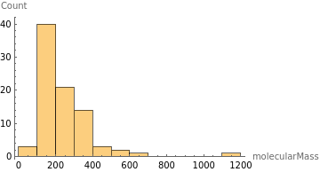